# GPR68 Deep Mutational Scan Multiphenotypic Analysis

Matthew Howard, UCSF

March 11, 2024

this notebook contains code used to analyze multiphenotypic GPR68 deep mutational scanning data and prepare plots

screening conditions: pH 6.5, pH 5.5, and surface expression

abbreviations and general naming conventions: decimals are omitted when referring to pH conditions, example:"ph55” for pH 5.5

set working directory, reset to source folder on your system

source R packages

```r
library(patchwork)
```

pull in DMS data and gpr68 structure

```r
gpr68_structure <- read.pdb("structures/gpr68_structure.pdb")
```

```
Error in read.pdb("structures/gpr68_structure.pdb") :
  No input PDB file found: check filename
```

define structure map function borrowed from Christian Macdonald’s (@UCSF) work as part of https://github.com/odcambc/DIMPLE_manuscript_figures

```r
# Function to map scores to a PDB structure based on residue numbers
# Input:
#   input_pdb: Input PDB structure
#   mapping_scores: Dataframe containing mapping scores
#   field: The field in the mapping_scores dataframe to use for scoring
#   selection: Optional selection of atoms, default is "protein"

map_scores_pdb <- function(input_pdb, mapping_scores, field, selection = NULL) {

  # If selection is not provided, select all atoms in the "protein" segment
  if (is.null(selection)) {
    selection = atom.select(input_pdb, "protein")
  }

  # Trim the PDB structure to the selected atoms
  output_pdb = trim.pdb(input_pdb, selection)

  # Loop through each atom in the trimmed PDB structure
  for (i in seq_len(dim(output_pdb$atom)[1])) {

    # Check if the residue number is greater than 0
    if (output_pdb$atom[i,]$resno > 0) {

      # Convert the residue number to a character
      n = as.character(output_pdb$atom[i,]$resno)

      # Find the corresponding row in mapping_scores where 'pos' matches the residue number
      j = which(mapping_scores['pos'] == n)

      # Check if there is a matching row in mapping_scores
      if (length(j) == 0) {
        score = 0
      } else {
        # Get the score from the specified field in the matching row
        score = mapping_scores[j, field][[1]]
      }

      # Check if the score is not NA (not missing)
      if (!is.na(score)) {
        # Update the 'b' column in the PDB structure with the score
        output_pdb$atom[i,]$b = score
      } else {
        # If the score is missing, set 'b' to 0
        output_pdb$atom[i,]$b = 0
      }
    } else {
      # If the residue number is not greater than 0, set 'b' to 0
      output_pdb$atom[i,]$b = 0
    }
  }

  # Return the PDB structure with updated scores
  return(output_pdb)
}
```

make scatter of expression vs function scores, fit line to syn population, calculate euclidean distance from line for all variants, above line are GOF below line are LOF make waterfall plot averaging distances/position for positive (GOF) and negative (LOF) distances

```r
# generate plots, use only gpr68_scores_missense df
ph55_distance <- scatter_waterfalls(gpr68_scores_missense, "surf_score", "ph55_score",y_var_for_line = "ph55_score", "main/figure4/GPR68_surf_ph55_scatter.pdf", "supplemental/supp_figure17/GPR68_surf_ph55_ranked_pos.pdf")
# generate plots, use only gpr68_scores_missense df
ph55_distance <- scatter_waterfalls(gpr68_scores_missense, "surf_score", "ph55_score",y_var_for_line = "ph55_score", "main/figure4/GPR68_surf_ph55_scatter.pdf", "supplemental/supp_figure17/GPR68_surf_ph55_ranked_pos.pdf")
ph65_distance <- scatter_waterfalls(gpr68_scores_missense, "surf_score", "ph65_score",y_var_for_line = "ph65_score", "main/figure4/GPR68_surf_ph65_scatter.pdf", "supplemental/supp_figure17/GPR68_surf_ph65_ranked_pos.pdf")
```

map GOF/LOF scores to structure

```r
x = map_scores_pdb(gpr68_structure, ph55_distance[[1]], "mean_distance")
ca.chainsABC<-atom.select(x, 'calpha', chain = c('R'))
write.pdb(x, file="main/figure5/GPR68_ph55_GOF.pdb")

x = map_scores_pdb(gpr68_structure, ph55_distance[[2]], "mean_distance")
ca.chainsABC<-atom.select(x, 'calpha', chain = c('R'))
write.pdb(x, file="main/figure5/GPR68_ph55_LOF.pdb")

x = map_scores_pdb(gpr68_structure, ph65_distance[[1]], "mean_distance")
ca.chainsABC<-atom.select(x, 'calpha', chain = c('R'))
write.pdb(x, file="main/figure5/GPR68_ph65_GOF.pdb")

x = map_scores_pdb(gpr68_structure, ph65_distance[[2]], "mean_distance")
ca.chainsABC<-atom.select(x, 'calpha', chain = c('R'))
write.pdb(x, file="main/figure5/GPR68_ph65_LOF.pdb")
```

make boxplot of all surface-adusted ph55 scores and then subset of the ones around the pocket

simply make a group column, pocket 1, 2, rest and then plot the violins w/barplot on top using ggviolin define pocket 1, 2, both, rest pocket 1:13, 14, 15, 17,20,28,77,80,85,101,102,164,165,166,167,169,171,172,174,175,176,265,269,272,273 pocket 2: 102, 156, 162, 173, 174, 178, 181, 182, 186, 189, 244, 248, 251, 268

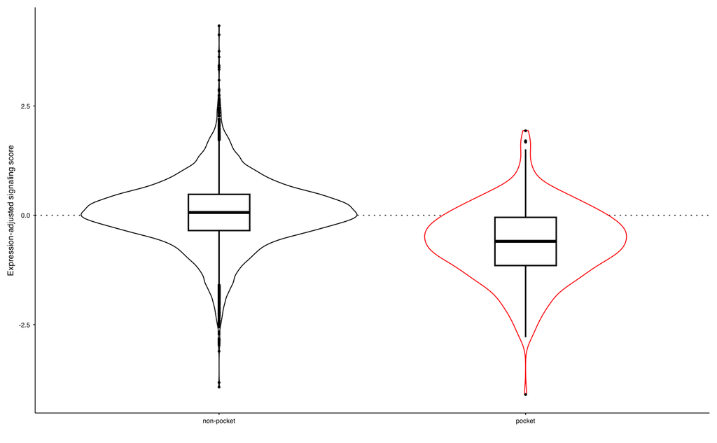

```r
ph55_distance_scores <- ph55_distance[[3]]

ph55_distance_scores$group <- "non-pocket"
#define groups, remove 13, 14, 165, 166, 167 from pocket 1 as the side chains point into extracellular space
ph55_distance_scores$group <- ifelse(
    ph55_distance_scores$pos %in% c(15, 17,20,28,77,80,85,101,102,164,169,171,172,174,175,176,265,269,272,273),
    "pocket",ph55_distance_scores$group)

violins <- ggplot(ph55_distance_scores, aes(x = group, y = distance, color = group)) +
  geom_hline(yintercept = 0, linetype = "dotted", color = "black", size = 0.3) +
  geom_violin(size = 0.3) +
  geom_boxplot(width = 0.2, color = "black", outlier.size = 0.3, size = 0.5) +
  theme_minimal() +
  labs(x = "",
       y = "Expression-adjusted signaling score") +
  scale_color_manual(values = c("non-pocket" = "black", "pocket" = "red")) +  # Set fill colors for each group
  theme(legend.position = "none",
        panel.grid.major = element_blank(),
        panel.grid.minor = element_blank(),
        axis.line = element_line(color = "black", size = 0.25),
        text = element_text(size = 6, family = "sans"),
        axis.text = element_text(color = "black"),
        axis.ticks = element_line(color = "black", size = 0.25),
        axis.ticks.length = unit(0.05, "cm")) +
  scale_y_continuous(breaks = c(-2.5, 0, 2.5))

violins

ggsave("main/figure5/ph55_violins.pdf", violins, width = 30, height = 55, units = "mm", dpi = 600)
```

```r
# stats testing

# Subset the data for each group
nonpocket_data <- ph55_distance_scores$distance[ph55_distance_scores$group == "non-pocket"]
pocket_data <- ph55_distance_scores$distance[ph55_distance_scores$group == "pocket"]

# Perform t-test
t_test_result <- t.test(nonpocket_data, pocket_data)

# Print the result
print(t_test_result)
```

```
    Welch Two Sample t-test

data:  nonpocket_data and pocket_data
t = 15.388, df = 425.28, p-value < 2.2e-16
alternative hypothesis: true difference in means is not equal to 0
95 percent confidence interval:
 0.5870510 0.7589805
sample estimates:
  mean of x   mean of y
 0.04790622 -0.62510951
```

```r
# Perform Mann-Whitney U test
wilcox_test_result <- wilcox.test(nonpocket_data, pocket_data)

# Print the result
print(wilcox_test_result)
```

```
    Wilcoxon rank sum test with continuity correction

data:  nonpocket_data and pocket_data
W = 1902988, p-value < 2.2e-16
alternative hypothesis: true location shift is not equal to 0
```

histidine heatmap snapshots, could be better code but it works

```r
# filter the ph55_distance_sum_signed[[3]] data frame to histidine residues
ph55_his <- ph55_distance_sum_signed[[3]] %>% filter(pos %in% c(17,20,84,89,159,169,175,245,269))

# in the pos column of ph55_his change each occurrance of 17 to 1, 20 to 2, 84 to 3, 89 to 4, 159 to 5, 169 to 6, 175 to 7, 245 to 8, 269 to 9
ph55_his$pos <- recode(ph55_his$pos, "17" = "2", "20" = "3", "84" = "4", "89" = "5", "159" = "6", "169" = "7", "175" = "8", "245" = "9", "269" = "10")

order_missense <- c("A", "G", "M", "V", "L", "I", "T", "S", "C", "Q", "N", "Y", "W", "F", "E", "D", "H", "K", "R", "P")
label_missense <- c("A", "G", "M", "V", "L", "I", "T", "S", "C", "Q", "N", "Y", "W", "F", "E", "D", "H", "K", "R", "P")
ph55_his$distance <- as.numeric(ph55_his$distance)
ph55_his$pos <- as.numeric(ph55_his$pos)

# add a row to ph55_his for each position, except pos = 8, and set the variatns to H
ph55_his <- ph55_his %>% add_row(pos = 1, variants = "H") %>% add_row(pos = 2, variants = "H") %>% add_row(pos = 3, variants = "H") %>% add_row(pos = 4, variants = "H") %>% add_row(pos = 5, variants = "H") %>% add_row(pos = 6, variants = "H") %>% add_row(pos = 7, variants = "H") %>% add_row(pos = 9, variants = "H") %>% add_row(pos = 10, variants = "H")

# add a row to ph55_his for pos = 8, set the distane to 0 and set the variatns to T
ph55_his <- ph55_his %>% add_row(pos = 8, variants = "T", distance = NA)
ph55_his <- ph55_his %>% add_row(pos = 8, variants = "C", distance = NA)

create_heatmap <- function(gene, order, chunk_size, scores_df, score_column, variant_names = NULL, output_file = NULL) {

  # Check if variant_names were provided; if not, use the original variant names
  if (is.null(variant_names)) {
    variant_names <- order
  }

  scores_df <- scores_df %>%
    filter(variants %in% order)

  gene_chunks <- str_split(gene, '')[[1]]
  num_chunks <- ceiling(length(gene_chunks) / chunk_size)

  min_score <- min(scores_df[, score_column], na.rm = TRUE)
  max_score <- max(scores_df[, score_column], na.rm = TRUE)

  heatmap_plots <- list()

  for (i in 1:num_chunks) {
    start_idx <- (i - 1) * chunk_size + 1
    end_idx <- min(i * chunk_size, length(gene_chunks))

    gene_chunk <- gene_chunks[start_idx:end_idx]
    scores_chunk <- scores_df[scores_df$pos %in% c(start_idx:(start_idx + length(gene_chunk) - 1)), ]

    # Replace the variant names with the desired names
    scores_chunk$variants <- factor(scores_chunk$variants, levels = order, labels = variant_names)


    heatmap_plot <- ggplot(data = scores_chunk, aes(x = pos, y = factor(variants, level = variant_names), fill = !!sym(score_column))) +
      geom_tile(aes(color = "grey"), linewidth = 0.2, position = "identity") +
      scale_fill_continuous_divergingx(palette = 'RdBu', mid = 0, l1 = 0.2, l3 = 0.2, p1 = 0.9, p3 = .4, p4 = 0.7, rev = FALSE, na.value = 'grey', limits = c(min_score, max_score)) +
theme(
        panel.background = element_rect(fill = "grey", size = 0.1, linetype = "solid"),
        panel.grid.major = element_line(size = 0.3, linetype = 'solid', colour = "grey"),
        panel.grid.minor = element_blank(),
        #axis.ticks.x = element_blank(),
        axis.ticks.x.top = element_blank(),
        axis.ticks.y = element_blank(),
        axis.text.x = element_text(family = "sans", size = 9, angle = 0, hjust = 0.5, vjust = 1, margin = margin(t = 1)),
        axis.text = element_text(family = "sans", size = 9, color = "black"),
        axis.text.x.top = element_text(family = "sans",  size = 9, angle = 0, hjust = 0.5, margin = margin(r = 0)),
        axis.text.y = element_text(family = "sans",  size = 9,  margin = margin(r = 0)) ) +
      scale_x_continuous(breaks = seq(0, nchar(gene), by = 5), expand = c(0, 0),
                         sec.axis = sec_axis(trans = ~., name = "Sequence", breaks = seq(start_idx, end_idx), labels = gene_chunk, guide = derive())) +
      coord_fixed(ratio = 1) +
      theme(axis.text.y = element_blank(),
            axis.title.y = element_blank()) +
      scale_color_manual(values = c(NA, 'grey'), guide = FALSE) +
      labs(x = "Position") +

      geom_tile(data = subset(scores_chunk, !is.wt), aes(color = "grey"), size = 0.2, position = "identity", show.legend = FALSE) +
      geom_tile(data = subset(scores_chunk, is.wt), aes(color = "grey"), size = 0.2, position = "identity", show.legend = FALSE)

    heatmap_plots[[i]] <- heatmap_plot
  }
  #heatmap_combined <- ggarrange(plotlist = heatmap_plots, nrow = num_chunks, ncol = 1)

  # Assuming heatmap_plots is your list of plots
    subset_plots <- heatmap_plots[2:10]

    # Use patchwork::wrap_plots with the subset_plots
    heatmap_combined <- patchwork::wrap_plots(subset_plots, nrow = 1, ncol = length(subset_plots)) +
  plot_layout(guides = 'collect')


  #heatmap_combined <- patchwork::wrap_plots(heatmap_plots, nrow = 1, ncol = num_chunks)
    ggsave(output_file, heatmap_combined, height = 20, width = 10, dpi = 450)
}






create_heatmap(gene = histidine_seq, order = order_missense, chunk_size = 1, scores_df = ph55_his, score_column = "distance", variant_names = label_missense, output_file = "main/figure5/histidine_heatmap.pdf")
```

DRY&DPxxY heatmap snapshots, could also be more elegant.

```r
# filter the ph55_distance_sum_signed[[3]] data frame to DRY and DPxxY motifs
order_missense <- c("A", "G", "M", "V", "L", "I", "T", "S", "C", "Q", "N", "Y", "W", "F", "E", "D", "H", "K", "R", "P")
label_missense <- c("A", "G", "M", "V", "L", "I", "T", "S", "C", "Q", "N", "Y", "W", "F", "E", "D", "H", "K", "R", "P")

dpxxy <- ph55_distance_sum_signed[[3]] %>% filter(pos %in% c(282,283,284,285,286))
dpxxy$pos <- recode(dpxxy$pos,"282" = "1", "283" = "2", "284" = "3", "285" = "4", "286" = "5")
dpxxy$distance <- as.numeric(dpxxy$distance)
dpxxy$pos <- as.numeric(dpxxy$pos)

dry <- ph55_distance_sum_signed[[3]] %>% filter(pos %in% c(118,119,120))
dry$pos <- recode(dry$pos, "118" = "1", "119" = "2", "120" = "3")
dry$distance <- as.numeric(dry$distance)
dry$pos <- as.numeric(dry$pos)

create_heatmap <- function(gene, order, chunk_size, scores_df, score_column, variant_names = NULL, output_file = NULL) {

  # Check if variant_names were provided; if not, use the original variant names
  if (is.null(variant_names)) {
    variant_names <- order
  }

  scores_df <- scores_df %>%
    filter(variants %in% order)

  gene_chunks <- str_split(gene, '')[[1]]
  num_chunks <- ceiling(length(gene_chunks) / chunk_size)

  min_score <- min(scores_df[, score_column], na.rm = TRUE)
  max_score <- max(scores_df[, score_column], na.rm = TRUE)

  heatmap_plots <- list()

  for (i in 1:num_chunks) {
    start_idx <- (i - 1) * chunk_size + 1
    end_idx <- min(i * chunk_size, length(gene_chunks))

    gene_chunk <- gene_chunks[start_idx:end_idx]
    scores_chunk <- scores_df[scores_df$pos %in% c(start_idx:(start_idx + length(gene_chunk) - 1)), ]

    # Replace the variant names with the desired names
    scores_chunk$variants <- factor(scores_chunk$variants, levels = order, labels = variant_names)

    heatmap_plot <- ggplot(data = scores_chunk, aes(x = pos, y = factor(variants, level = variant_names), fill = !!sym(score_column))) +
      geom_tile(aes(color = "grey"), linewidth = 0.2, position = "identity") +
      scale_fill_continuous_divergingx(palette = 'RdBu', mid = 0, l1 = 0.2, l3 = 0.2, p1 = 0.9, p3 = .4, p4 = 0.7, rev = FALSE, na.value = 'grey', limits = c(min_score, max_score)) +
theme(
        panel.background = element_rect(fill = "grey", size = 0.1, linetype = "solid"),
        panel.grid.major = element_line(size = 0.3, linetype = 'solid', colour = "grey"),
        panel.grid.minor = element_blank(),
        #axis.ticks.x = element_blank(),
        axis.ticks.x.top = element_blank(),
        axis.ticks.y = element_blank(),
        axis.text.x = element_text(family = "sans", size = 9, angle = 0, hjust = 0.5, vjust = 1, margin = margin(t = 1)),
        axis.text = element_text(family = "sans", size = 9, color = "black"),
        axis.text.x.top = element_text(family = "sans",  size = 9, angle = 0, hjust = 0.5, margin = margin(r = 0)),
        axis.text.y = element_text(family = "sans",  size = 9,  margin = margin(r = 0)) ) +
      scale_x_continuous(breaks = seq(0, nchar(gene), by = 5), expand = c(0, 0),
                         sec.axis = sec_axis(trans = ~., name = "Sequence", breaks = seq(start_idx, end_idx), labels = gene_chunk, guide = derive())) +
      coord_fixed(ratio = 1) +
      theme(axis.text.y = element_blank(),
            axis.title.y = element_blank()) +
      scale_color_manual(values = c(NA, 'grey'), guide = FALSE) +
      labs(x = "Position") +

      geom_tile(data = subset(scores_chunk, !is.wt), aes(color = "grey"), size = 0.2, position = "identity", show.legend = FALSE) +
      geom_tile(data = subset(scores_chunk, is.wt), aes(color = "grey"), size = 0.2, position = "identity", show.legend = FALSE)

    heatmap_plots[[i]] <- heatmap_plot
  }
  heatmap_combined <- ggarrange(plotlist = heatmap_plots, nrow = num_chunks, ncol = 1)

  heatmap_combined <- patchwork::wrap_plots(heatmap_plots, nrow = 1, ncol = num_chunks)
    ggsave(output_file, heatmap_combined, height = 20, width = 10, dpi = 450)
}

dry_seq <- "DRY"
dpxxy_seq <- "DPILY"

create_heatmap(gene = dry_seq, order = order_missense, chunk_size = 10, scores_df = dry, score_column = "distance", variant_names = label_missense, output_file = "supplemental/dry_heatmap.pdf")

create_heatmap(gene = dpxxy_seq, order = order_missense, chunk_size = 10, scores_df = dpxxy, score_column = "distance", variant_names = label_missense, output_file = "supplemental/dpxxy_heatmap.pdf")
```

heatmap of the ph55 surf-adjusted scores

```r
create_heatmap(gene = gpr68_wt, order = order_missense, chunk_size = 125, scores_df = ph55_distance_scores, score_column = "distance", variant_names = label_missense, output_file = "main/figure4/ph55_surf_adjusted_heatmap.pdf")
```